# Data 607 - Week 12 Assignment

Peter Kowalchuk

11/10/2018

```r
library(kableExtra)
```

# NoSQL migration

The flights database will be migrated from MySQL to MongoDB. TO do this the tables in the flights database in MySQL will be read into r dataframes, which will then be exported to a MongoDB.

## MySQL

Data is stored in MySQL is a database (schema) called flights, with 5 tables:

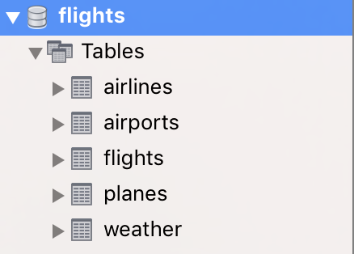

We connect to MySQL and load all the tables in the flights database into dataframes which are added to a list.

```r
library(RMySQL)
con <- dbConnect(MySQL(), user='root', password='123', dbname='flights', host='localhost')
tablesNamesSQL <- dbListTables(con)
tablesSQL<-list()

for(i in 1:length(tablesNamesSQL)){
  tablesSQL[[i]]<-data.frame(dbReadTable(con,tablesNamesSQL[i]))
}
names(tablesSQL)<-tablesNamesSQL
```

We inspect the dataframes to see if the data was loaded.

```r
inspectDataFrameList<-function(dataFrameList) {
  cat("\n Names of data frames \n\n")
  print(names(dataFrameList))
  cat(paste("\n Summay of airlines \n\n"))
  print(summary(dataFrameList$airlines))
  cat(paste("\n Summay of airports \n\n"))
  print(summary(dataFrameList$airports))
  cat(paste("\n Summay of flights \n\n"))
  print(summary(dataFrameList$flights))
  cat(paste("\n Summay of planes \n\n"))
  print(summary(dataFrameList$planes))
  cat(paste("\n Summay of weather \n\n"))
  print(summary(dataFrameList$weather))
  cat(paste("\n Head of airlines \n\n"))
  print(kable(head(dataFrameList$airlines,n=20)))
  cat(paste("\n\n Head of airports \n\n"))
  print(kable(head(dataFrameList$airports,n=20)))
  cat(paste("\n\n Head of flights \n\n"))
  print(kable(head(dataFrameList$flights,n=20)))
  cat(paste("\n\n Head of planes \n\n"))
  print(kable(head(dataFrameList$planes,n=20)))
  cat(paste("\n\n Head of weather \n\n"))
  print(kable(head(dataFrameList$weather,n=20)))
}

inspectDataFrameList(tablesSQL)
```

Names of data frames

[1] “airlines” “airports” “flights” “planes” “weather”

Summay of airlines

carrier name  
Length:16 Length:16  
Class :character Class :character  
Mode :character Mode :character

Summay of airports

```
 faa                name                lat             lon
```

Length:1397 Length:1397 Min. :19.72 Min. :-176.65  
Class :character Class :character 1st Qu.:34.27 1st Qu.:-119.32  
Mode :character Mode :character Median :40.14 Median : -94.91  
Mean :41.75 Mean :-103.69  
3rd Qu.:45.25 3rd Qu.: -82.54  
Max. :72.27 Max. : 174.11  
alt tz dst  
Min. : -54 Min. :-11.000 Length:1397  
1st Qu.: 70 1st Qu.: -8.000 Class :character  
Median : 483 Median : -6.000 Mode :character  
Mean :1006 Mean : -6.421  
3rd Qu.:1076 3rd Qu.: -5.000  
Max. :9078 Max. : 8.000

Summay of flights

```
  year          month             day           dep_time
```

Min. :2013 Min. : 1.000 Min. : 1.00 Min. : 1  
1st Qu.:2013 1st Qu.: 1.000 1st Qu.: 7.00 1st Qu.: 906  
Median :2013 Median :10.000 Median :14.00 Median :1357  
Mean :2013 Mean : 8.062 Mean :14.64 Mean :1344  
3rd Qu.:2013 3rd Qu.:11.000 3rd Qu.:22.00 3rd Qu.:1736  
Max. :2013 Max. :12.000 Max. :31.00 Max. :2400  
dep_delay arr_time arr_delay carrier  
Min. : -43.000 Min. : 1 Min. : -70.000 Length:95114  
1st Qu.: -5.000 1st Qu.:1116 1st Qu.: -16.000 Class :character  
Median : -2.000 Median :1547 Median : -5.000 Mode :character  
Mean : 8.356 Mean :1520 Mean : 4.105  
3rd Qu.: 6.000 3rd Qu.:1943 3rd Qu.: 11.000  
Max. :1301.000 Max. :2400 Max. :1272.000  
tailnum flight origin dest  
Length:95114 Min. : 1 Length:95114 Length:95114  
Class :character 1st Qu.: 523 Class :character Class :character  
Mode :character Median :1493 Mode :character Mode :character  
Mean :1954  
3rd Qu.:3386  
Max. :8500  
air_time distance hour minute  
Min. : 20 Min. : 80 Min. : 0.00 Min. : 0.00  
1st Qu.: 85 1st Qu.: 502 1st Qu.: 9.00 1st Qu.:17.00  
Median :133 Median : 872 Median :13.00 Median :32.00  
Mean :154 Mean :1039 Mean :13.12 Mean :32.09  
3rd Qu.:195 3rd Qu.:1389 3rd Qu.:17.00 3rd Qu.:50.00  
Max. :676 Max. :4983 Max. :24.00 Max. :59.00

Summay of planes

tailnum year type manufacturer  
Length:3182 Min. : -14 Length:3182 Length:3182  
Class :character 1st Qu.: 67 Class :character Class :character  
Mode :character Median :1998 Mode :character Mode :character  
Mean :1437  
3rd Qu.:2003  
Max. :2013  
model engines seats speed  
Length:3182 Min. : 1.0 Min. : 0.0 Length:3182  
Class :character 1st Qu.: 2.0 1st Qu.: 17.0 Class :character  
Mode :character Median : 2.0 Median :140.0 Mode :character  
Mean : 606.9 Mean :107.3  
3rd Qu.:1243.0 3rd Qu.:178.0  
Max. :2351.0 Max. :450.0  
engine  
Length:3182  
Class :character  
Mode :character

Summay of weather

```
origin               year          month             day
```

Length:3972 Min. :2013 Min. : 1.0 Min. : 1.00  
Class :character 1st Qu.:2013 1st Qu.: 4.0 1st Qu.: 8.00  
Mode :character Median :2013 Median : 7.0 Median :16.00  
Mean :2013 Mean : 122.8 Mean :15.77  
3rd Qu.:2013 3rd Qu.: 11.0 3rd Qu.:23.00  
Max. :2013 Max. :4963.0 Max. :31.00  
hour temp dewp humid  
Min. : 0.00 Min. :-16.00 Min. :-9.04 Min. : 1.00  
1st Qu.: 7.00 1st Qu.: 30.02 1st Qu.:24.98 1st Qu.: 54.43  
Median :12.00 Median : 48.02 Median :41.00 Median : 81.95  
Mean :11.86 Mean : 45.75 Mean :40.54 Mean : 836.22  
3rd Qu.:17.00 3rd Qu.: 68.00 3rd Qu.:57.02 3rd Qu.:1120.00  
Max. :23.00 Max. :262.00 Max. :75.92 Max. :6181.00  
wind_dir wind_speed wind_gust precip Min. : 0.0 Min. : 0.000 Min. : 0.000 Min. :0  
1st Qu.:120.0 1st Qu.: 9.206 1st Qu.: 6.622 1st Qu.:0  
Median :230.0 Median : 701.000 Median : 10.594 Median :0  
Mean :196.6 Mean : 738.039 Mean : 11.111 Mean :0  
3rd Qu.:280.0 3rd Qu.:1439.000 3rd Qu.: 14.567 3rd Qu.:0  
Max. :360.0 Max. :2357.000 Max. :1206.432 Max. :0  
pressure visib  
Min. : 986.4 Min. : 0.000  
1st Qu.:1012.7 1st Qu.:10.000  
Median :1017.5 Median :10.000  
Mean :1017.7 Mean : 9.565  
3rd Qu.:1022.8 3rd Qu.:10.000  
Max. :1041.9 Max. :10.000

Head of airlines

| carrier | name |
| --- | --- |
| 9E | Endeavor Air Inc. |
| AA | American Airlines Inc. |
| AS | Alaska Airlines Inc. |
| B6 | JetBlue Airways |
| DL | Delta Air Lines Inc. |
| EV | ExpressJet Airlines Inc. |
| F9 | Frontier Airlines Inc. |
| FL | AirTran Airways Corporation |
| HA | Hawaiian Airlines Inc. |
| MQ | Envoy Air |
| OO | SkyWest Airlines Inc. |
| UA | United Air Lines Inc. |
| US | US Airways Inc. |
| VX | Virgin America |
| WN | Southwest Airlines Co. |
| YV | Mesa Airlines Inc. |

Head of airports

| faa | name | lat | lon | alt | tz | dst |
| --- | --- | --- | --- | --- | --- | --- |
| 04G | Lansdowne Airport | 41.13047 | -80.61958 | 1044 | -5 | A |
| 06A | Moton Field Municipal Airport | 32.46057 | -85.68003 | 264 | -5 | A |
| 06C | Schaumburg Regional | 41.98934 | -88.10124 | 801 | -6 | A |
| 06N | Randall Airport | 41.43191 | -74.39156 | 523 | -5 | A |
| 09J | Jekyll Island Airport | 31.07447 | -81.42778 | 11 | -4 | A |
| 0A9 | Elizabethton Municipal Airport | 36.37122 | -82.17342 | 1593 | -4 | A |
| 0G6 | Williams County Airport | 41.46731 | -84.50678 | 730 | -5 | A |
| 0G7 | Finger Lakes Regional Airport | 42.88356 | -76.78123 | 492 | -5 | A |
| 0P2 | Shoestring Aviation Airfield | 39.79482 | -76.64719 | 1000 | -5 | U |
| 0S9 | Jefferson County Intl | 48.05381 | -122.81064 | 108 | -8 | A |
| 0W3 | Harford County Airport | 39.56684 | -76.20240 | 409 | -5 | A |
| 10C | Galt Field Airport | 42.40289 | -88.37511 | 875 | -6 | U |
| 17G | Port Bucyrus-Crawford County Airport | 40.78156 | -82.97481 | 1003 | -5 | A |
| 19A | Jackson County Airport | 34.17586 | -83.56160 | 951 | -4 | U |
| 1A3 | Martin Campbell Field Airport | 35.01581 | -84.34683 | 1789 | -4 | A |
| 1B9 | Mansfield Municipal | 42.00013 | -71.19677 | 122 | -5 | A |
| 1C9 | Frazier Lake Airpark | 54.01333 | -124.76833 | 152 | -8 | A |
| 1CS | Clow International Airport | 41.69597 | -88.12923 | 670 | -6 | U |
| 1G3 | Kent State Airport | 41.15139 | -81.41511 | 1134 | -4 | A |
| 1OH | Fortman Airport | 40.55533 | -84.38662 | 885 | -5 | U |

Head of flights

| year | month | day | dep_time | dep_delay | arr_time | arr_delay | carrier | tailnum | flight | origin | dest | air_time | distance | hour | minute |
| --- | --- | --- | --- | --- | --- | --- | --- | --- | --- | --- | --- | --- | --- | --- | --- |
| 2013 | 1 | 1 | 517 | 2 | 830 | 11 | UA | N14228 | 1545 | EWR | IAH | 227 | 1400 | 5 | 17 |
| 2013 | 1 | 1 | 533 | 4 | 850 | 20 | UA | N24211 | 1714 | LGA | IAH | 227 | 1416 | 5 | 33 |
| 2013 | 1 | 1 | 542 | 2 | 923 | 33 | AA | N619AA | 1141 | JFK | MIA | 160 | 1089 | 5 | 42 |
| 2013 | 1 | 1 | 544 | -1 | 1004 | -18 | B6 | N804JB | 725 | JFK | BQN | 183 | 1576 | 5 | 44 |
| 2013 | 1 | 1 | 554 | -6 | 812 | -25 | DL | N668DN | 461 | LGA | ATL | 116 | 762 | 5 | 54 |
| 2013 | 1 | 1 | 554 | -4 | 740 | 12 | UA | N39463 | 1696 | EWR | ORD | 150 | 719 | 5 | 54 |
| 2013 | 1 | 1 | 555 | -5 | 913 | 19 | B6 | N516JB | 507 | EWR | FLL | 158 | 1065 | 5 | 55 |
| 2013 | 1 | 1 | 557 | -3 | 709 | -14 | EV | N829AS | 5708 | LGA | IAD | 53 | 229 | 5 | 57 |
| 2013 | 1 | 1 | 557 | -3 | 838 | -8 | B6 | N593JB | 79 | JFK | MCO | 140 | 944 | 5 | 57 |
| 2013 | 1 | 1 | 558 | -2 | 753 | 8 | AA | N3ALAA | 301 | LGA | ORD | 138 | 733 | 5 | 58 |
| 2013 | 1 | 1 | 558 | -2 | 849 | -2 | B6 | N793JB | 49 | JFK | PBI | 149 | 1028 | 5 | 58 |
| 2013 | 1 | 1 | 558 | -2 | 853 | -3 | B6 | N657JB | 71 | JFK | TPA | 158 | 1005 | 5 | 58 |
| 2013 | 1 | 1 | 558 | -2 | 924 | 7 | UA | N29129 | 194 | JFK | LAX | 345 | 2475 | 5 | 58 |
| 2013 | 1 | 1 | 558 | -2 | 923 | -14 | UA | N53441 | 1124 | EWR | SFO | 361 | 2565 | 5 | 58 |
| 2013 | 1 | 1 | 559 | -1 | 941 | 31 | AA | N3DUAA | 707 | LGA | DFW | 257 | 1389 | 5 | 59 |
| 2013 | 1 | 1 | 559 | 0 | 702 | -4 | B6 | N708JB | 1806 | JFK | BOS | 44 | 187 | 5 | 59 |
| 2013 | 1 | 1 | 559 | -1 | 854 | -8 | UA | N76515 | 1187 | EWR | LAS | 337 | 2227 | 5 | 59 |
| 2013 | 1 | 1 | 600 | 0 | 851 | -7 | B6 | N595JB | 371 | LGA | FLL | 152 | 1076 | 6 | 0 |
| 2013 | 1 | 1 | 600 | 0 | 837 | 12 | MQ | N542MQ | 4650 | LGA | ATL | 134 | 762 | 6 | 0 |
| 2013 | 1 | 1 | 601 | 1 | 844 | -6 | B6 | N644JB | 343 | EWR | PBI | 147 | 1023 | 6 | 1 |

Head of planes

| tailnum | year | type | manufacturer | model | engines | seats | speed | engine |
| --- | --- | --- | --- | --- | --- | --- | --- | --- |
| N10156 | 2004 | Fixed wing multi engine | EMBRAER | EMB-145XR | 2 | 55 |  | Turbo-fan |
| N102UW | 6 | Fixed wing multi engine | AIRBUS INDUSTRIE | A320-214 | 817 | 8 | 1783 | JFK |
| N103US | 1999 | Fixed wing multi engine | AIRBUS INDUSTRIE | A320-214 | 2 | 182 |  | Turbo-fan |
| 419 | -8 | 12 | AIRBUS INDUSTRIE | CLE | 817 | 8 | 3272 | LGA |
| N10575 | 2002 | Fixed wing multi engine | EMBRAER | EMB-145LR | 2 | 55 |  | LGA |
| N105UW | 1999 | Fixed wing multi engine | AIRBUS INDUSTRIE | A320-214 | 2 | 182 |  | Turbo-fan |
| N107US | 1999 | Fixed wing multi engine | AIRBUS INDUSTRIE | A320-214 | 819 | 8 | 1626 | EWR |
| N108UW | 1999 | Fixed wing multi engine | AIRBUS INDUSTRIE | A320-214 | 2 | 182 |  | Turbo-fan |
| 228 | 140 | Fixed wing multi engine | AIRBUS INDUSTRIE | IAD | 820 | 8 | 5716 | JFK |
| N110UW | 1999 | Fixed wing multi engine | AIRBUS INDUSTRIE | A320-214 | 2 | 182 |  | Turbo-fan |
| N11106 | 2002 | Fixed wing multi engine | EMBRAER | EMB-145XR | 2 | 55 |  | Turbo-fan |
| N11107 | 2002 | Fixed wing multi engine | EMBRAER | EMB-145XR | 821 | 55 | 3528 | LGA |
| N11109 | 2002 | Fixed wing multi engine | EMBRAER | EMB-145XR | 2 | 55 |  | Turbo-fan |
| 292 | 6 | Fixed wing multi engine | EMBRAER | EMB-145XR | 821 | 8 | 4213 | LGA |
| N11119 | 2002 | Fixed wing multi engine | EMBRAER | EMB-145XR | 2 | 55 |  | Turbo-fan |
| 2133 | -2 | 12 | 301 | PHX | 821 | 8 | 1043 | EWR |
| N11127 | 2003 | Fixed wing multi engine | EMBRAER | EMB-145XR | 821 | 55 |  | JFK |
| N11137 | 2003 | Fixed wing multi engine | EMBRAER | EMB-145XR | 2 | 55 |  | Turbo-fan |
| N11140 | 2003 | Fixed wing multi engine | EMBRAER | EMB-145XR | 822 | 8 | 2912 | JFK |
| N11150 | 2003 | Fixed wing multi engine | EMBRAER | EMB-145XR | 2 | 55 |  | Turbo-fan |

Head of weather

| origin | year | month | day | hour | temp | dewp | humid | wind_dir | wind_speed | wind_gust | precip | pressure | visib |
| --- | --- | --- | --- | --- | --- | --- | --- | --- | --- | --- | --- | --- | --- |
| EWR | 2013 | 1 | 1 | 0 | 37.04 | 21.92 | 4152.00 | 230 | 2130.00000 | 11.918651 | 0 | 1013.9 | 10 |
| EWR | 2013 | 1 | 1 | 1 | 37.04 | 21.92 | 53.97 | 230 | 13.80936 | 15.891535 | 0 | 1013.0 | 10 |
| EWR | 2013 | 1 | 1 | 2 | 37.94 | 21.92 | 52.09 | 230 | 12.65858 | 14.567241 | 0 | 1012.6 | 10 |
| JFK | 2013 | 1005 | 1 | 21 | -3.00 | 28.04 | 425.00 | 240 | 2138.00000 | 13.242946 | 0 | 1012.5 | 10 |
| JFK | 2013 | 1 | 1 | 21 | 39.92 | 28.04 | 1183.00 | 250 | 2140.00000 | 14.567241 | 0 | 1012.2 | 10 |
| JFK | 2013 | 1 | 1 | 10 | 39.02 | 28.04 | 64.43 | 260 | 2144.00000 | 14.567241 | 0 | 1011.9 | 10 |
| EWR | 2013 | 1 | 1 | 11 | 37.94 | 28.04 | 67.21 | 240 | 11.50780 | 13.242946 | 0 | 1012.4 | 10 |
| EWR | 2013 | 1 | 1 | 12 | 39.02 | 28.04 | 64.43 | 240 | 14.96014 | 17.215830 | 0 | 1012.2 | 10 |
| JFK | 2013 | 1 | 1 | 19 | 39.02 | 24.08 | 54.68 | 280 | 13.80936 | 15.891535 | 0 | 1010.8 | 10 |
| EWR | 2013 | 1 | 1 | 20 | 37.94 | 24.08 | 57.04 | 290 | 9.20624 | 10.594357 | 0 | 1011.9 | 10 |
| LGA | 2013 | 431 | 2 | 22 | 93.00 | 15.08 | 3257.00 | 310 | 2213.00000 | 17.215830 | 0 | 1015.2 | 10 |
| EWR | 2013 | 1 | 2 | 2 | 30.02 | 12.92 | 4645.00 | 320 | 2215.00000 | 21.188714 | 0 | 1016.0 | 10 |
| JFK | 2013 | 1 | 2 | 3 | 28.94 | 12.02 | 48.69 | 320 | 18.41248 | 21.188714 | 0 | 1016.5 | 10 |
| EWR | 2013 | 1 | 2 | 4 | 28.04 | 10.94 | 48.15 | 310 | 16.11092 | 18.540125 | 0 | 1016.4 | 10 |
| JFK | 2013 | 1 | 2 | 22 | 145.00 | 8.96 | 2454.00 | 320 | 2220.00000 | 17.215830 | 0 | 1016.6 | 10 |
| LGA | 2013 | 1 | 2 | 9 | 24.08 | 8.96 | 3660.00 | 330 | 2222.00000 | 14.567241 | 0 | 1016.9 | 10 |
| EWR | 2013 | 1 | 2 | 10 | 24.08 | 8.96 | 51.93 | 330 | 6.90468 | 7.945768 | 0 | 1016.9 | 10 |
| EWR | 2013 | 1 | 2 | 11 | 24.08 | 8.96 | 51.93 | 310 | 3.45234 | 3.972884 | 0 | 1017.2 | 10 |
| JFK | 2013 | 2521 | 2 | 22 | 182.00 | 12.02 | 161.00 | 300 | 2234.00000 | 17.215830 | 0 | 1017.5 | 10 |
| JFK | 2013 | 1 | 2 | 22 | 32.00 | 12.92 | 2599.00 | 290 | 2236.00000 | 14.567241 | 0 | 1017.1 | 10 |

## MongoDB

The databrames containing the SQL tables are stored into collections in MongoDB.

```r
library(mongolite)
```

```r
for(i in 1:length(tablesNamesSQL)){
  c<-mongo(collection = tablesNamesSQL[i],db="flights")
  c$insert(tablesSQL[[i]])
}
```

A flights database is created containing a collection for each dataframe.

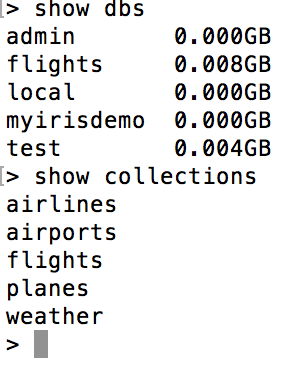

Each row of data in the dataframes is stored as a document in the respective collection. Here is an example for airlines:

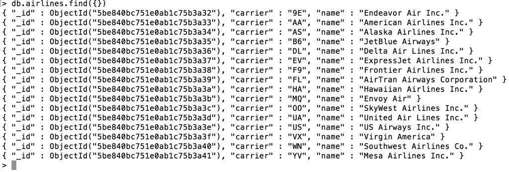

The data is read back into r. We read all the collections available in the flights database stored in MongoDB.

```r
c<-mongo(db="flights")
p<-c$run('{"listCollections":1}')
collectionsNamesMongo <- p$cursor$firstBatch$name
collectionsMongo<-list()

for(i in 1:length(collectionsNamesMongo)){
  c<-mongo(collection = collectionsNamesMongo[i],db="flights")
  collectionsMongo[[i]]<-c$find('{}')
}
names(collectionsMongo)<-collectionsNamesMongo
```

We inspect the collections to see if the data was loaded.

```r
inspectDataFrameList(collectionsMongo)
```

Names of data frames

[1] “planes” “flights” “airports” “airlines” “weather”

Summay of airlines

carrier name  
Length:16 Length:16  
Class :character Class :character  
Mode :character Mode :character

Summay of airports

```
 faa                name                lat             lon
```

Length:1397 Length:1397 Min. :19.72 Min. :-176.65  
Class :character Class :character 1st Qu.:34.27 1st Qu.:-119.32  
Mode :character Mode :character Median :40.14 Median : -94.91  
Mean :41.75 Mean :-103.69  
3rd Qu.:45.25 3rd Qu.: -82.54  
Max. :72.27 Max. : 174.11  
alt tz dst  
Min. : -54 Min. :-11.000 Length:1397  
1st Qu.: 70 1st Qu.: -8.000 Class :character  
Median : 483 Median : -6.000 Mode :character  
Mean :1006 Mean : -6.421  
3rd Qu.:1076 3rd Qu.: -5.000  
Max. :9078 Max. : 8.000

Summay of flights

```
  year          month             day           dep_time
```

Min. :2013 Min. : 1.000 Min. : 1.00 Min. : 1  
1st Qu.:2013 1st Qu.: 1.000 1st Qu.: 7.00 1st Qu.: 906  
Median :2013 Median :10.000 Median :14.00 Median :1357  
Mean :2013 Mean : 8.062 Mean :14.64 Mean :1344  
3rd Qu.:2013 3rd Qu.:11.000 3rd Qu.:22.00 3rd Qu.:1736  
Max. :2013 Max. :12.000 Max. :31.00 Max. :2400  
dep_delay arr_time arr_delay carrier  
Min. : -43.000 Min. : 1 Min. : -70.000 Length:95114  
1st Qu.: -5.000 1st Qu.:1116 1st Qu.: -16.000 Class :character  
Median : -2.000 Median :1547 Median : -5.000 Mode :character  
Mean : 8.356 Mean :1520 Mean : 4.105  
3rd Qu.: 6.000 3rd Qu.:1943 3rd Qu.: 11.000  
Max. :1301.000 Max. :2400 Max. :1272.000  
tailnum flight origin dest  
Length:95114 Min. : 1 Length:95114 Length:95114  
Class :character 1st Qu.: 523 Class :character Class :character  
Mode :character Median :1493 Mode :character Mode :character  
Mean :1954  
3rd Qu.:3386  
Max. :8500  
air_time distance hour minute  
Min. : 20 Min. : 80 Min. : 0.00 Min. : 0.00  
1st Qu.: 85 1st Qu.: 502 1st Qu.: 9.00 1st Qu.:17.00  
Median :133 Median : 872 Median :13.00 Median :32.00  
Mean :154 Mean :1039 Mean :13.12 Mean :32.09  
3rd Qu.:195 3rd Qu.:1389 3rd Qu.:17.00 3rd Qu.:50.00  
Max. :676 Max. :4983 Max. :24.00 Max. :59.00

Summay of planes

tailnum year type manufacturer  
Length:3182 Min. : -14 Length:3182 Length:3182  
Class :character 1st Qu.: 67 Class :character Class :character  
Mode :character Median :1998 Mode :character Mode :character  
Mean :1437  
3rd Qu.:2003  
Max. :2013  
model engines seats speed  
Length:3182 Min. : 1.0 Min. : 0.0 Length:3182  
Class :character 1st Qu.: 2.0 1st Qu.: 17.0 Class :character  
Mode :character Median : 2.0 Median :140.0 Mode :character  
Mean : 606.9 Mean :107.3  
3rd Qu.:1243.0 3rd Qu.:178.0  
Max. :2351.0 Max. :450.0  
engine  
Length:3182  
Class :character  
Mode :character

Summay of weather

```
origin               year          month             day
```

Length:3972 Min. :2013 Min. : 1.0 Min. : 1.00  
Class :character 1st Qu.:2013 1st Qu.: 4.0 1st Qu.: 8.00  
Mode :character Median :2013 Median : 7.0 Median :16.00  
Mean :2013 Mean : 122.8 Mean :15.77  
3rd Qu.:2013 3rd Qu.: 11.0 3rd Qu.:23.00  
Max. :2013 Max. :4963.0 Max. :31.00  
hour temp dewp humid  
Min. : 0.00 Min. :-16.00 Min. :-9.04 Min. : 1.00  
1st Qu.: 7.00 1st Qu.: 30.02 1st Qu.:24.98 1st Qu.: 54.43  
Median :12.00 Median : 48.02 Median :41.00 Median : 81.95  
Mean :11.86 Mean : 45.75 Mean :40.54 Mean : 836.22  
3rd Qu.:17.00 3rd Qu.: 68.00 3rd Qu.:57.02 3rd Qu.:1120.00  
Max. :23.00 Max. :262.00 Max. :75.92 Max. :6181.00  
wind_dir wind_speed wind_gust precip Min. : 0.0 Min. : 0.000 Min. : 0.000 Min. :0  
1st Qu.:120.0 1st Qu.: 9.206 1st Qu.: 6.622 1st Qu.:0  
Median :230.0 Median : 701.000 Median : 10.594 Median :0  
Mean :196.6 Mean : 738.039 Mean : 11.111 Mean :0  
3rd Qu.:280.0 3rd Qu.:1439.000 3rd Qu.: 14.567 3rd Qu.:0  
Max. :360.0 Max. :2357.000 Max. :1206.432 Max. :0  
pressure visib  
Min. : 986.4 Min. : 0.000  
1st Qu.:1012.7 1st Qu.:10.000  
Median :1017.5 Median :10.000  
Mean :1017.7 Mean : 9.565  
3rd Qu.:1022.8 3rd Qu.:10.000  
Max. :1041.9 Max. :10.000

Head of airlines

| carrier | name |
| --- | --- |
| 9E | Endeavor Air Inc. |
| AA | American Airlines Inc. |
| AS | Alaska Airlines Inc. |
| B6 | JetBlue Airways |
| DL | Delta Air Lines Inc. |
| EV | ExpressJet Airlines Inc. |
| F9 | Frontier Airlines Inc. |
| FL | AirTran Airways Corporation |
| HA | Hawaiian Airlines Inc. |
| MQ | Envoy Air |
| OO | SkyWest Airlines Inc. |
| UA | United Air Lines Inc. |
| US | US Airways Inc. |
| VX | Virgin America |
| WN | Southwest Airlines Co. |
| YV | Mesa Airlines Inc. |

Head of airports

| faa | name | lat | lon | alt | tz | dst |
| --- | --- | --- | --- | --- | --- | --- |
| 04G | Lansdowne Airport | 41.13047 | -80.61958 | 1044 | -5 | A |
| 06A | Moton Field Municipal Airport | 32.46057 | -85.68003 | 264 | -5 | A |
| 06C | Schaumburg Regional | 41.98934 | -88.10124 | 801 | -6 | A |
| 06N | Randall Airport | 41.43191 | -74.39156 | 523 | -5 | A |
| 09J | Jekyll Island Airport | 31.07447 | -81.42778 | 11 | -4 | A |
| 0A9 | Elizabethton Municipal Airport | 36.37122 | -82.17342 | 1593 | -4 | A |
| 0G6 | Williams County Airport | 41.46731 | -84.50678 | 730 | -5 | A |
| 0G7 | Finger Lakes Regional Airport | 42.88356 | -76.78123 | 492 | -5 | A |
| 0P2 | Shoestring Aviation Airfield | 39.79482 | -76.64719 | 1000 | -5 | U |
| 0S9 | Jefferson County Intl | 48.05381 | -122.81064 | 108 | -8 | A |
| 0W3 | Harford County Airport | 39.56684 | -76.20240 | 409 | -5 | A |
| 10C | Galt Field Airport | 42.40289 | -88.37511 | 875 | -6 | U |
| 17G | Port Bucyrus-Crawford County Airport | 40.78156 | -82.97481 | 1003 | -5 | A |
| 19A | Jackson County Airport | 34.17586 | -83.56160 | 951 | -4 | U |
| 1A3 | Martin Campbell Field Airport | 35.01581 | -84.34683 | 1789 | -4 | A |
| 1B9 | Mansfield Municipal | 42.00013 | -71.19677 | 122 | -5 | A |
| 1C9 | Frazier Lake Airpark | 54.01333 | -124.76833 | 152 | -8 | A |
| 1CS | Clow International Airport | 41.69597 | -88.12923 | 670 | -6 | U |
| 1G3 | Kent State Airport | 41.15139 | -81.41511 | 1134 | -4 | A |
| 1OH | Fortman Airport | 40.55533 | -84.38662 | 885 | -5 | U |

Head of flights

| year | month | day | dep_time | dep_delay | arr_time | arr_delay | carrier | tailnum | flight | origin | dest | air_time | distance | hour | minute |
| --- | --- | --- | --- | --- | --- | --- | --- | --- | --- | --- | --- | --- | --- | --- | --- |
| 2013 | 1 | 1 | 517 | 2 | 830 | 11 | UA | N14228 | 1545 | EWR | IAH | 227 | 1400 | 5 | 17 |
| 2013 | 1 | 1 | 533 | 4 | 850 | 20 | UA | N24211 | 1714 | LGA | IAH | 227 | 1416 | 5 | 33 |
| 2013 | 1 | 1 | 542 | 2 | 923 | 33 | AA | N619AA | 1141 | JFK | MIA | 160 | 1089 | 5 | 42 |
| 2013 | 1 | 1 | 544 | -1 | 1004 | -18 | B6 | N804JB | 725 | JFK | BQN | 183 | 1576 | 5 | 44 |
| 2013 | 1 | 1 | 554 | -6 | 812 | -25 | DL | N668DN | 461 | LGA | ATL | 116 | 762 | 5 | 54 |
| 2013 | 1 | 1 | 554 | -4 | 740 | 12 | UA | N39463 | 1696 | EWR | ORD | 150 | 719 | 5 | 54 |
| 2013 | 1 | 1 | 555 | -5 | 913 | 19 | B6 | N516JB | 507 | EWR | FLL | 158 | 1065 | 5 | 55 |
| 2013 | 1 | 1 | 557 | -3 | 709 | -14 | EV | N829AS | 5708 | LGA | IAD | 53 | 229 | 5 | 57 |
| 2013 | 1 | 1 | 557 | -3 | 838 | -8 | B6 | N593JB | 79 | JFK | MCO | 140 | 944 | 5 | 57 |
| 2013 | 1 | 1 | 558 | -2 | 753 | 8 | AA | N3ALAA | 301 | LGA | ORD | 138 | 733 | 5 | 58 |
| 2013 | 1 | 1 | 558 | -2 | 849 | -2 | B6 | N793JB | 49 | JFK | PBI | 149 | 1028 | 5 | 58 |
| 2013 | 1 | 1 | 558 | -2 | 853 | -3 | B6 | N657JB | 71 | JFK | TPA | 158 | 1005 | 5 | 58 |
| 2013 | 1 | 1 | 558 | -2 | 924 | 7 | UA | N29129 | 194 | JFK | LAX | 345 | 2475 | 5 | 58 |
| 2013 | 1 | 1 | 558 | -2 | 923 | -14 | UA | N53441 | 1124 | EWR | SFO | 361 | 2565 | 5 | 58 |
| 2013 | 1 | 1 | 559 | -1 | 941 | 31 | AA | N3DUAA | 707 | LGA | DFW | 257 | 1389 | 5 | 59 |
| 2013 | 1 | 1 | 559 | 0 | 702 | -4 | B6 | N708JB | 1806 | JFK | BOS | 44 | 187 | 5 | 59 |
| 2013 | 1 | 1 | 559 | -1 | 854 | -8 | UA | N76515 | 1187 | EWR | LAS | 337 | 2227 | 5 | 59 |
| 2013 | 1 | 1 | 600 | 0 | 851 | -7 | B6 | N595JB | 371 | LGA | FLL | 152 | 1076 | 6 | 0 |
| 2013 | 1 | 1 | 600 | 0 | 837 | 12 | MQ | N542MQ | 4650 | LGA | ATL | 134 | 762 | 6 | 0 |
| 2013 | 1 | 1 | 601 | 1 | 844 | -6 | B6 | N644JB | 343 | EWR | PBI | 147 | 1023 | 6 | 1 |

Head of planes

| tailnum | year | type | manufacturer | model | engines | seats | speed | engine |
| --- | --- | --- | --- | --- | --- | --- | --- | --- |
| N10156 | 2004 | Fixed wing multi engine | EMBRAER | EMB-145XR | 2 | 55 |  | Turbo-fan |
| N102UW | 6 | Fixed wing multi engine | AIRBUS INDUSTRIE | A320-214 | 817 | 8 | 1783 | JFK |
| N103US | 1999 | Fixed wing multi engine | AIRBUS INDUSTRIE | A320-214 | 2 | 182 |  | Turbo-fan |
| 419 | -8 | 12 | AIRBUS INDUSTRIE | CLE | 817 | 8 | 3272 | LGA |
| N10575 | 2002 | Fixed wing multi engine | EMBRAER | EMB-145LR | 2 | 55 |  | LGA |
| N105UW | 1999 | Fixed wing multi engine | AIRBUS INDUSTRIE | A320-214 | 2 | 182 |  | Turbo-fan |
| N107US | 1999 | Fixed wing multi engine | AIRBUS INDUSTRIE | A320-214 | 819 | 8 | 1626 | EWR |
| N108UW | 1999 | Fixed wing multi engine | AIRBUS INDUSTRIE | A320-214 | 2 | 182 |  | Turbo-fan |
| 228 | 140 | Fixed wing multi engine | AIRBUS INDUSTRIE | IAD | 820 | 8 | 5716 | JFK |
| N110UW | 1999 | Fixed wing multi engine | AIRBUS INDUSTRIE | A320-214 | 2 | 182 |  | Turbo-fan |
| N11106 | 2002 | Fixed wing multi engine | EMBRAER | EMB-145XR | 2 | 55 |  | Turbo-fan |
| N11107 | 2002 | Fixed wing multi engine | EMBRAER | EMB-145XR | 821 | 55 | 3528 | LGA |
| N11109 | 2002 | Fixed wing multi engine | EMBRAER | EMB-145XR | 2 | 55 |  | Turbo-fan |
| 292 | 6 | Fixed wing multi engine | EMBRAER | EMB-145XR | 821 | 8 | 4213 | LGA |
| N11119 | 2002 | Fixed wing multi engine | EMBRAER | EMB-145XR | 2 | 55 |  | Turbo-fan |
| 2133 | -2 | 12 | 301 | PHX | 821 | 8 | 1043 | EWR |
| N11127 | 2003 | Fixed wing multi engine | EMBRAER | EMB-145XR | 821 | 55 |  | JFK |
| N11137 | 2003 | Fixed wing multi engine | EMBRAER | EMB-145XR | 2 | 55 |  | Turbo-fan |
| N11140 | 2003 | Fixed wing multi engine | EMBRAER | EMB-145XR | 822 | 8 | 2912 | JFK |
| N11150 | 2003 | Fixed wing multi engine | EMBRAER | EMB-145XR | 2 | 55 |  | Turbo-fan |

Head of weather

| origin | year | month | day | hour | temp | dewp | humid | wind_dir | wind_speed | wind_gust | precip | pressure | visib |
| --- | --- | --- | --- | --- | --- | --- | --- | --- | --- | --- | --- | --- | --- |
| EWR | 2013 | 1 | 1 | 0 | 37.04 | 21.92 | 4152.00 | 230 | 2130.00000 | 11.918651 | 0 | 1013.9 | 10 |
| EWR | 2013 | 1 | 1 | 1 | 37.04 | 21.92 | 53.97 | 230 | 13.80936 | 15.891535 | 0 | 1013.0 | 10 |
| EWR | 2013 | 1 | 1 | 2 | 37.94 | 21.92 | 52.09 | 230 | 12.65858 | 14.567241 | 0 | 1012.6 | 10 |
| JFK | 2013 | 1005 | 1 | 21 | -3.00 | 28.04 | 425.00 | 240 | 2138.00000 | 13.242946 | 0 | 1012.5 | 10 |
| JFK | 2013 | 1 | 1 | 21 | 39.92 | 28.04 | 1183.00 | 250 | 2140.00000 | 14.567241 | 0 | 1012.2 | 10 |
| JFK | 2013 | 1 | 1 | 10 | 39.02 | 28.04 | 64.43 | 260 | 2144.00000 | 14.567241 | 0 | 1011.9 | 10 |
| EWR | 2013 | 1 | 1 | 11 | 37.94 | 28.04 | 67.21 | 240 | 11.50780 | 13.242946 | 0 | 1012.4 | 10 |
| EWR | 2013 | 1 | 1 | 12 | 39.02 | 28.04 | 64.43 | 240 | 14.96014 | 17.215830 | 0 | 1012.2 | 10 |
| JFK | 2013 | 1 | 1 | 19 | 39.02 | 24.08 | 54.68 | 280 | 13.80936 | 15.891535 | 0 | 1010.8 | 10 |
| EWR | 2013 | 1 | 1 | 20 | 37.94 | 24.08 | 57.04 | 290 | 9.20624 | 10.594357 | 0 | 1011.9 | 10 |
| LGA | 2013 | 431 | 2 | 22 | 93.00 | 15.08 | 3257.00 | 310 | 2213.00000 | 17.215830 | 0 | 1015.2 | 10 |
| EWR | 2013 | 1 | 2 | 2 | 30.02 | 12.92 | 4645.00 | 320 | 2215.00000 | 21.188714 | 0 | 1016.0 | 10 |
| JFK | 2013 | 1 | 2 | 3 | 28.94 | 12.02 | 48.69 | 320 | 18.41248 | 21.188714 | 0 | 1016.5 | 10 |
| EWR | 2013 | 1 | 2 | 4 | 28.04 | 10.94 | 48.15 | 310 | 16.11092 | 18.540125 | 0 | 1016.4 | 10 |
| JFK | 2013 | 1 | 2 | 22 | 145.00 | 8.96 | 2454.00 | 320 | 2220.00000 | 17.215830 | 0 | 1016.6 | 10 |
| LGA | 2013 | 1 | 2 | 9 | 24.08 | 8.96 | 3660.00 | 330 | 2222.00000 | 14.567241 | 0 | 1016.9 | 10 |
| EWR | 2013 | 1 | 2 | 10 | 24.08 | 8.96 | 51.93 | 330 | 6.90468 | 7.945768 | 0 | 1016.9 | 10 |
| EWR | 2013 | 1 | 2 | 11 | 24.08 | 8.96 | 51.93 | 310 | 3.45234 | 3.972884 | 0 | 1017.2 | 10 |
| JFK | 2013 | 2521 | 2 | 22 | 182.00 | 12.02 | 161.00 | 300 | 2234.00000 | 17.215830 | 0 | 1017.5 | 10 |
| JFK | 2013 | 1 | 2 | 22 | 32.00 | 12.92 | 2599.00 | 290 | 2236.00000 | 14.567241 | 0 | 1017.1 | 10 |

## Verification SQL vs MongoDB

```r
if(tablesSQL$airlines==collectionsMongo$airlines &&
   tablesSQL$airports==collectionsMongo$airports &&
   tablesSQL$flights==collectionsMongo$flights &&
   tablesSQL$planes==collectionsMongo$planes &&
   tablesSQL$weather==collectionsMongo$weather) {
  print("Data in both databases is the same")
} else {
  print("Data is not the same in both databases")
}
```

```
## [1] "Data in both databases is the same"
```

## SQL(MySQL) vs. non-SQL(MongoDB)

Data stored in both databases can be imported to equal dataframes. But the SQL database is more conducive to operations where data from different tables needs to be related. For example using primary keys in tables and performing joins. Data in Mongo sits in collections which are not natively related, although MongoDB offers a SQL abstraction. Also, rows of data in Mongo are stored as documents with an identifier for each. This seems excessive and overweight. But the idea of collections open the option of storing documents of different kinds within the collection. This means that we can potentially store all of our dataframes in Mongo under the same collection, even as each data frame contains different columns. This is not possible in SQL, where to do this we would have to add columns for all the tables, thus creating data that is very space since columns will only be used when data for the respective table is present, and will be empty otherwise. In Mongo, event with our current setup where we have different collections for the different dataframes, if data were missing for a specific column for different rows, those columns will simply not be present in the collection. This reduces sparsity compared to SQL.

The following is a comparison table (source: https://hackernoon.com/mongodb-vs-mysql-comparison-which-database-is-better-e714b699c38b)

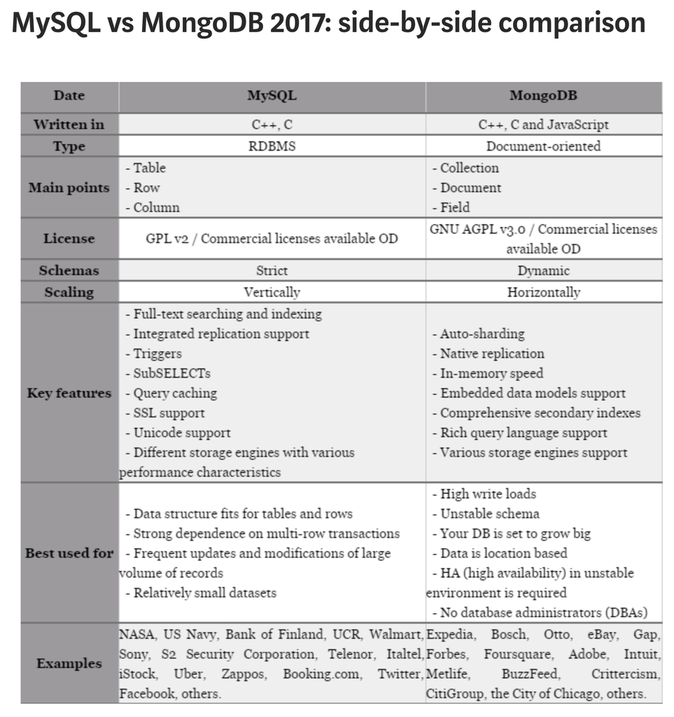